# Wybór najlepszego modelu do predykcji zmiennych dotyczących transakcji bankowych

### Zbudowanie drzewa bez jednostek odbiegających

Ponownie oszacowano model - tym razem bez jednostek odbiegających, dzięki czemu zredukowano liczbę punktów podziału do 10.

```r
new.drzewo.reg <- rpart(amount ~. -id - createtime, data = nowa_regresja)
new.drzewo.reg$cptable
```

```
##            CP nsplit rel error    xerror       xstd
## 1  0.28889993      0 1.0000000 1.0000528 0.02551625
## 2  0.07362107      1 0.7111001 0.7113324 0.01939029
## 3  0.05809522      2 0.6374790 0.6381862 0.01795813
## 4  0.03313091      3 0.5793838 0.5803457 0.01580990
## 5  0.02873092      5 0.5131220 0.5142664 0.01395147
## 6  0.01410727      6 0.4843911 0.4864259 0.01293709
## 7  0.01312613      7 0.4702838 0.4737388 0.01277244
## 8  0.01278225      8 0.4571577 0.4673790 0.01264408
## 9  0.01037465      9 0.4443754 0.4502819 0.01247802
## 10 0.01000000     10 0.4340008 0.4423775 0.01233420
```

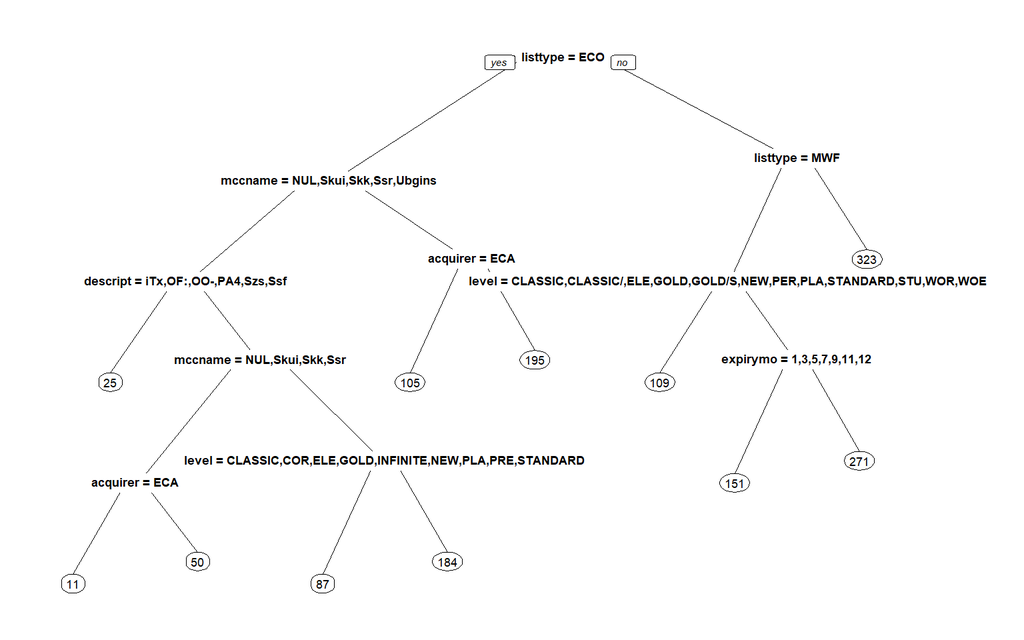

```r
prp(new.drzewo.reg)
```

```r
rsq.rpart(new.drzewo.reg)
```

```
##
## Regression tree:
## rpart(formula = amount ~ . - id - createtime, data = nowa_regresja)
##
## Variables actually used in tree construction:
## [1] acquirerconnectionmethod description              expirymonth
## [4] level                    listtype                 mccname
##
## Root node error: 100228118/25113 = 3991.1
##
## n= 25113
##
##          CP nsplit rel error  xerror     xstd
## 1  0.288900      0   1.00000 1.00005 0.025516
## 2  0.073621      1   0.71110 0.71133 0.019390
## 3  0.058095      2   0.63748 0.63819 0.017958
## 4  0.033131      3   0.57938 0.58035 0.015810
## 5  0.028731      5   0.51312 0.51427 0.013951
## 6  0.014107      6   0.48439 0.48643 0.012937
## 7  0.013126      7   0.47028 0.47374 0.012772
## 8  0.012782      8   0.45716 0.46738 0.012644
## 9  0.010375      9   0.44438 0.45028 0.012478
## 10 0.010000     10   0.43400 0.44238 0.012334
```

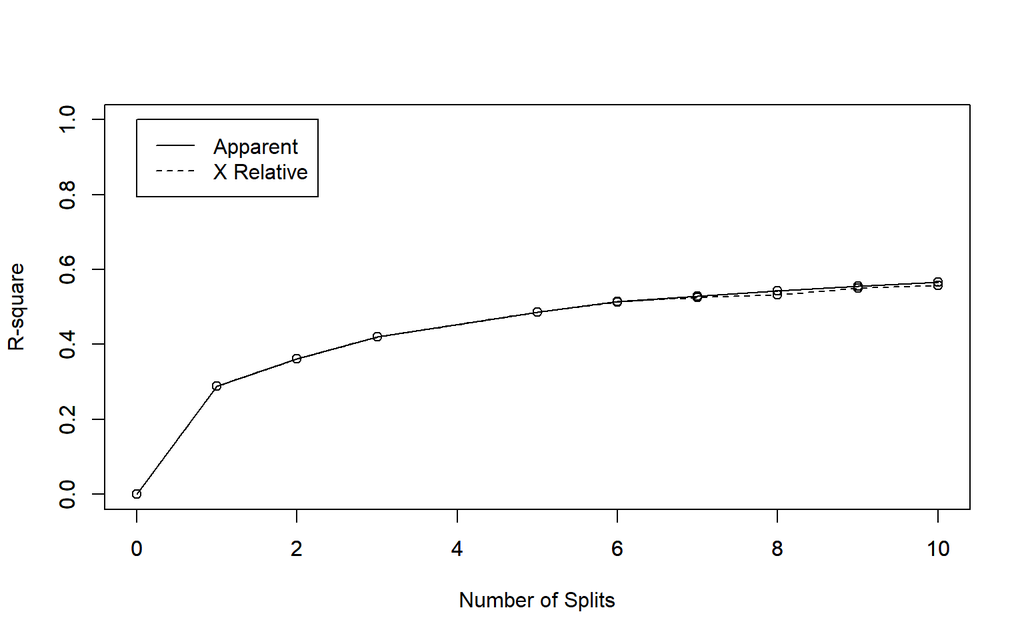

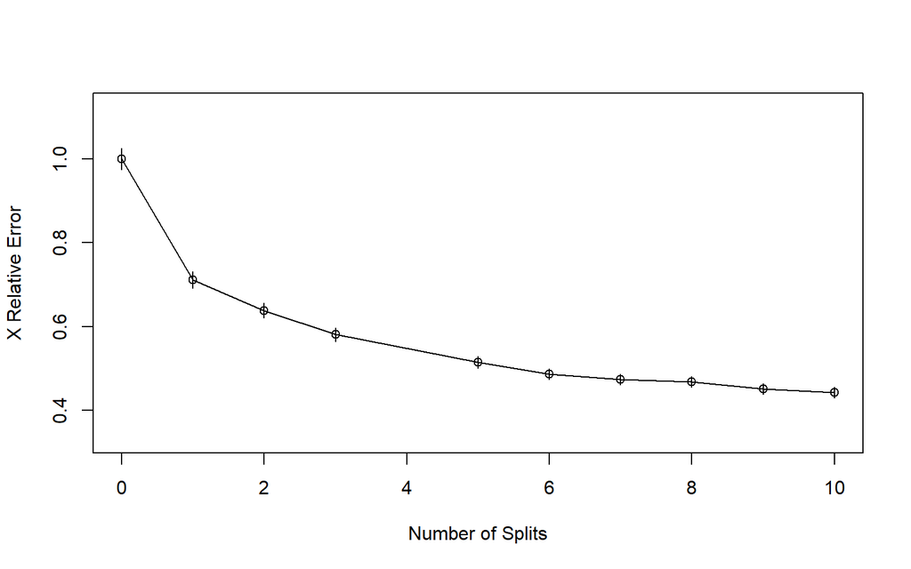

### Sumy kwadratów reszt dla drzewa przyciętego

Ponownie wartości sum kwadratów reszt są stosunkowo wysokie, lecz zmalało względem pierwszego drzewa.

```r
y <- nowa_regresja$amount
sum((y-mean(y))^2)
```

```
## [1] 100228118
```

```r
ss <- function (x) sum((x-mean(x))^2)
ss(y)
```

```
## [1] 100228118
```

```r
ss(y[nowa_regresja$listtype %in% c("ECOMMERCE")])
```

```
## [1] 30974521
```

```r
ss(y[!(nowa_regresja$listtype %in% c("ECOMMERCE"))])
```

```
## [1] 40297702
```

### Odczytanie ważności zmiennych

W ponownie oszacowanym modelu najistotniejszymi zmiennymi okazały się:

- **listtype**,
- **expiryyear**,
- **level**,
- **mccname**,
- **description**,
- **expirymonth**,
- **type**,
- **acquirerconnectionmethod**,
- **weekDay**,
- **countrycode**,
- **issuer**

czyli dokładnie takie same, jak w przypadku modelu uwzględniającego wartości odbiegające.

```r
drzewo.reg$variable.importance
```

```
##                 listtype               expiryyear                    level
##                101374739                 65370210                 34263262
##                  mccname              description              expirymonth
##                 29765041                 29251927                 28322838
##                     type acquirerconnectionmethod                  weekDay
##                  6791694                  5500343                  3575889
##              countrycode                   issuer
##                  3061892                  1867472
```

### Zbudowanie drzewa z parametrem cp = 0

Ponownie oszacowano maksymalne drzewo - tym razem z 1771 punktami podziału.

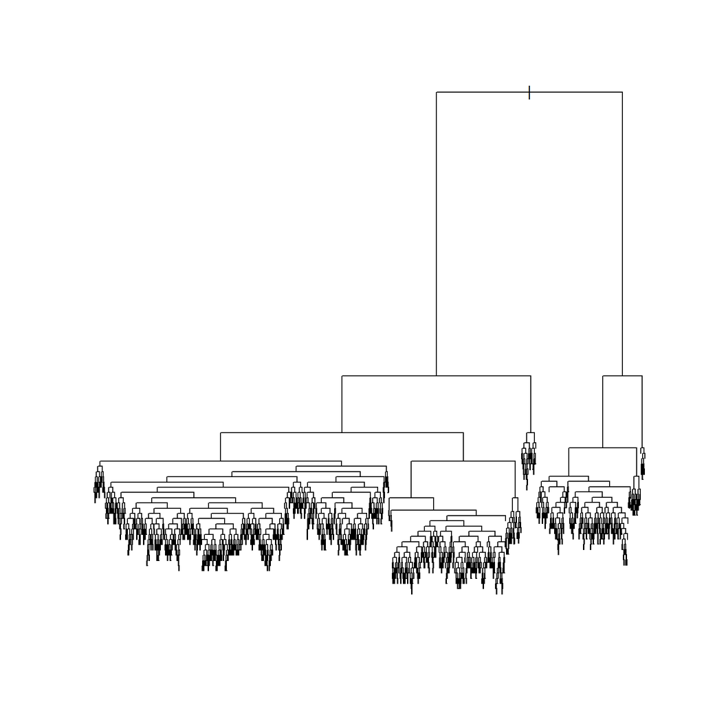

```r
new.drzewo.reg.big <- rpart(amount ~.-id-createtime, data = nowa_regresja, control = rpart.control(cp=0))
plot(new.drzewo.reg.big)
```

```r
tail(new.drzewo.reg.big$cptable,15)
```

```
##                CP nsplit rel error    xerror       xstd
## 1263 9.107720e-10   1755 0.1940535 0.2863907 0.01018472
## 1264 7.918445e-10   1756 0.1940535 0.2863907 0.01018472
## 1265 7.085286e-10   1757 0.1940535 0.2863907 0.01018472
## 1266 5.847467e-10   1758 0.1940535 0.2863907 0.01018472
## 1267 4.619093e-10   1759 0.1940535 0.2863907 0.01018472
## 1268 4.373129e-10   1760 0.1940535 0.2863907 0.01018472
## 1269 3.325747e-10   1761 0.1940535 0.2863907 0.01018472
## 1270 1.924570e-10   1762 0.1940535 0.2863907 0.01018472
## 1271 1.846568e-10   1763 0.1940535 0.2863907 0.01018472
## 1272 1.654052e-10   1764 0.1940535 0.2863907 0.01018472
## 1273 2.923733e-12   1765 0.1940535 0.2863907 0.01018472
## 1274 3.022331e-36   1766 0.1940535 0.2863907 0.01018472
## 1275 1.553143e-36   1767 0.1940535 0.2863907 0.01018472
## 1276 2.518609e-37   1770 0.1940535 0.2863907 0.01018472
## 1277 0.000000e+00   1771 0.1940535 0.2863907 0.01018472
```

```r
przycinanie <- function(new.drzewo.reg) {
  bledy <- new.drzewo.reg$cptable
  tmp1 <- which.min(bledy[, "xerror"])
  tmp2 <- sum(bledy[tmp1, c("xerror", "xstd")])
  optymalny <- which(bledy[, "xerror"] < tmp2)[1]

  prune(new.drzewo.reg, cp = bledy[optymalny, "CP"])
}

new.drzewo_przyciete.reg <- przycinanie(new.drzewo.reg.big)
```

### Przycięte drzewo regresyjne

Przycięcie drzewa spowodowało redukcję liczby punktów podziału do 155.

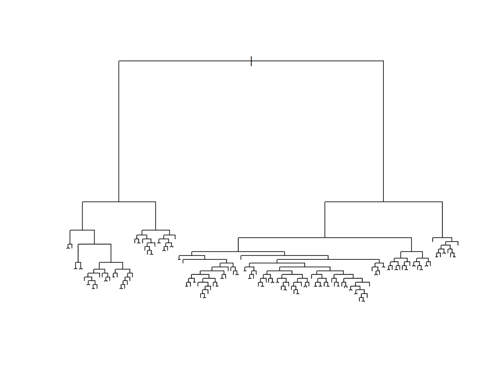

```r
plot(new.drzewo_przyciete.reg)
```

```r
rsq.rpart(new.drzewo_przyciete.reg)
```

```
##
## Regression tree:
## rpart(formula = amount ~ . - id - createtime, data = nowa_regresja,
##     control = rpart.control(cp = 0))
##
## Variables actually used in tree construction:
##  [1] acquirerconnectionmethod countrycode              description
##  [4] expirymonth              expiryyear               issuer
##  [7] level                    listtype                 mccname
## [10] type                     weekDay
##
## Root node error: 100228118/25113 = 3991.1
##
## n= 25113
##
```

[output cut: 99 more lines]

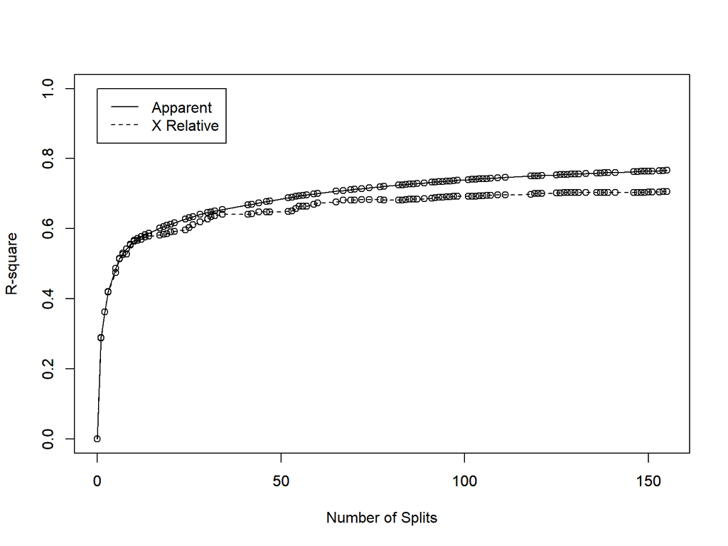

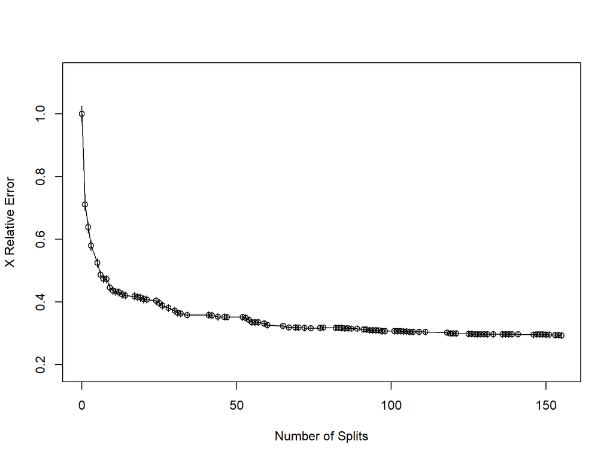

### Ważne miary dla przyciętego i nowego drzewa

Wartości wybranych miar uległy poprawie. Zmalał współczynnik indeterminacji, a zwiększyła się miara pseudo R2.

```r
sum((y - predict(new.drzewo_przyciete.reg))^2)
```

```
## [1] 23431795
```

```r
ss(y)
```

```
## [1] 100228118
```

```r
sum((y - predict(new.drzewo_przyciete.reg))^2)/ss(y)
```

```
## [1] 0.2337846
```

```r
1 - sum((y - predict(new.drzewo_przyciete.reg))^2)/ss(y)
```

```
## [1] 0.7662154
```

```r
drzewo.reg.pred.fin <- predict(new.drzewo_przyciete.reg, nowa_regresja)
RMSE.reg.drzewo.final <- RMSE(pred = drzewo.reg.pred.fin, obs = nowa_regresja$amount)
RMSE.reg.drzewo.final
```

```
## [1] 30.54594
```

### Zbudowanie modelu regresji liniowej

W celach porównawczych zbudowano również model regresji liniowej. Miara RMSE dla regresji liniowej jest wyższa niż dla drzew regresyjnych. Zostawienie wyłącznie zmiennych istotnych statystycznie w modelu umożliwiłoby prawdopodobnie na zmniejszenie RMSE.

```r
model <- lm(amount ~.-id-createtime, data = nowa_uczaca)
summary(model)
```

```
##
## Call:
## lm(formula = amount ~ . - id - createtime, data = nowa_uczaca)
##
## Residuals:
##     Min      1Q  Median      3Q     Max
## -525.79  -16.77   -1.57    8.56 2459.66
##
## Coefficients: (3 not defined because of singularities)
##                                                            Estimate Std. Error
## (Intercept)                                               157.17008  108.22275
## descriptionBez ograniczen                                -125.34730   28.72541
## descriptionBrak opisu                                      10.03694   20.39392
## descriptioniTaxi                                         -209.68639   24.42535
## descriptionOrange Flex:                                  -164.14277   20.85325
## descriptionOrange On-line:                               -164.97225   20.89635
## descriptionPLAY - FAKTURA                                  24.28310   20.33455
## descriptionPrzejazd A4Go                                 -220.59254   21.03508
## descriptionRedBull Mobile - FAKTURA                       -71.74368   24.68422
## descriptionSzybkie sprawdzanie                           -156.69243   25.86195
## descriptionSzybkie sprawdzanie firmy                     -133.62525   31.89448
## acquirerconnectionmethodFDP_SOAP                           48.93581    3.13583
## expirymonth2                                                1.71621    3.25653
## expirymonth3                                               -1.29802    3.29941
## expirymonth4                                               -6.88793    3.32710
## expirymonth5                                               -4.53828    3.21795
## expirymonth6                                               -7.36743    3.27497
## expirymonth7                                               -5.74382    3.27149
## expirymonth8                                               -7.50951    3.15984
## expirymonth9                                               -7.41989    3.15941
## expirymonth10                                              -2.57498    3.19885
## expirymonth11                                              -3.15193    3.26803
## expirymonth12                                             -17.30460    3.41861
## expiryyear2021                                             -0.69015    6.31722
## expiryyear2022                                              1.29773    6.21071
## expiryyear2023                                             11.51898    6.19310
## expiryyear2024                                              3.20706    6.20747
## expiryyear2025                                              5.14764    6.38026
## expiryyear2026                                            -13.88852    8.27819
## expiryyear2027                                            -30.43395   27.34865
```

[output cut: 184 more lines]

```
## mccnameSklepy spożywcze różne                            -13.526  < 2e-16 ***
## mccnameUbezpieczenia                                      -4.264 2.02e-05 ***
## mccnameUsługi biznesowe gdzie indziej nie sklasyfikowane  -2.728  0.00637 **
## weekDaywtorek                                              0.638  0.52345
## weekDayśroda                                               1.301  0.19341
## weekDayczwartek                                           -0.233  0.81553
## weekDaypiątek                                              0.718  0.47249
## weekDaysobota                                              0.112  0.91072
## weekDayniedziela                                           0.875  0.38174
## ---
## Signif. codes:  0 '***' 0.001 '**' 0.01 '*' 0.05 '.' 0.1 ' ' 1
##
## Residual standard error: 102 on 25343 degrees of freedom
## Multiple R-squared:  0.3615, Adjusted R-squared:  0.3588
## F-statistic: 134.1 on 107 and 25343 DF,  p-value: < 2.2e-16
```

```r
model.lm.pred <- predict(model, nowa_uczaca)
RMSE.model <- RMSE(pred = model.lm.pred, obs = nowa_uczaca$amount)
RMSE.model
```

```
## [1] 101.8221
```

### Zbudowanie modelu MARS

Wyniki modelu MARS prezentują się w następujący sposób:

```r
mars1 <- earth(formula = amount ~ .-id-createtime,
               data = nowa_uczaca,
               trace = 3)
```

```
## x[25451,110] with colnames descriptionBez ograniczen descriptionBrak opisu descripti...
## y[25451,1] with colname amount, and values 25, 25, 8, 25, 25, 25, 25, 22...
## Forward pass: minspan 10 endspan 14   x[25451,110] 21.4 MB   bx[25451,201] 39 MB
##
##          GRSq    RSq     DeltaRSq Pred     PredName         Cut  Terms   Par Deg
## 1      0.0000 0.0000                    (Intercept)
## 2      0.1645 0.1646       0.1646   98 listtypePUBL           0< 2             1
## 4      0.2451 0.2453      0.08066   97  listtypeMWF           0< 3             1
## 6      0.2623 0.2627      0.01736  103 mccnameUbezp           0< 4             1
## 8      0.2742 0.2746      0.01195   35 levelBUSINES           0< 5             1
## 10     0.2845 0.2851      0.01048   38 levelCORPORA           0< 6             1
## 12     0.2977 0.2983      0.01325    7 descriptionP           0< 7             1
## 14     0.3058 0.3066     0.008243   39 levelCORPORA           0< 8             1
## 16     0.3122 0.3131     0.006527    2 descriptionB           0< 9             1
## 18     0.3189 0.3198     0.006746  104 mccnameUsług           0< 10            1
## 20     0.3308 0.3319      0.01205    6 descriptionP           0< 11            1
## 22     0.3370 0.3382     0.006261  100 mccnameSieci           0< 12            1
## 24     0.3409 0.3422     0.003998   11 acquirerconn           0< 13            1
## 26     0.3468 0.3481     0.005948  102 mccnameSklep           0< 14            1
## 28     0.3490 0.3504     0.002283   34    typeDEBIT           0< 15            1
## 30     0.3502 0.3517     0.001334    8 descriptionR           0< 16            1
## 32     0.3511 0.3527    0.0009893   25 expiryyear20           0< 17            1 reject (small DeltaRSq)
##
## RSq changed by less than 0.001 at 31 terms, 16 terms used (DeltaRSq 0.00099)
## After forward pass GRSq 0.351 RSq 0.353
## Forward pass complete: 31 terms, 16 terms used
##
## Subset size        GRSq     RSq  DeltaGRSq nPreds
##           1      0.0000  0.0000     0.0000      0
##           2      0.1645  0.1646     0.1645      1
##           3      0.2451  0.2453     0.0806      2
##           4      0.2623  0.2627     0.0173      3
##           5      0.3090  0.3095     0.0467      4
##           6      0.3171  0.3177     0.0081      5
##           7      0.3244  0.3250     0.0073      6
##           8      0.3307  0.3315     0.0063      7
##           9      0.3367  0.3375     0.0059      8
##          10      0.3397  0.3406     0.0030      9
##          11      0.3428  0.3438     0.0031     10
##          12      0.3456  0.3467     0.0028     11
##          13      0.3479  0.3492     0.0024     12
##          14      0.3500  0.3514     0.0021     13
##          15      0.3501  0.3516     0.0001     14
## chosen   16      0.3502  0.3517     0.0001     15
##
## Prune backward penalty 2 nprune null: selected 16 of 16 terms, and 15 of 110 preds
## After pruning pass GRSq 0.35 RSq 0.352
```

```r
m <- mars1$bx

wezly <- mars1$dirs
wezly2 <- mars1$cuts

f2 <- mars1$prune.terms

summary(mars1)
```

```
## Call: earth(formula=amount~.-id-createtime, data=nowa_uczaca, trace=3)
##
##                                                          coefficients
## (Intercept)                                                  16.19920
## descriptionBrak opisu                                       161.97336
## descriptionPLAY - FAKTURA                                   172.49407
## descriptionPrzejazd A4Go                                    -51.46139
## descriptionRedBull Mobile - FAKTURA                          86.08166
## acquirerconnectionmethodFDP_SOAP                             42.09661
## typeDEBIT                                                   -18.11924
## levelBUSINESS                                                58.56295
## levelCORPORATE                                              175.54866
## levelCORPORATE T&E                                          579.04149
## listtypeMWF                                                 -63.28409
## listtypePUBLIC                                              299.22933
## mccnameSieci komputerowe usługi informacyjne               -156.06701
## mccnameSklepy spożywcze różne                              -190.57645
## mccnameUbezpieczenia                                        -30.92709
## mccnameUsługi biznesowe gdzie indziej nie sklasyfikowane    -15.87881
##
## Selected 16 of 16 terms, and 15 of 110 predictors
## Termination condition: RSq changed by less than 0.001 at 16 terms
## Importance: listtypePUBLIC, descriptionBrak opisu, ...
## Number of terms at each degree of interaction: 1 15 (additive model)
## GCV 10552.49    RSS 267917556    GRSq 0.3501861    RSq 0.3517171
```

```r
mars1$gcv.per.subset
```

```
##  [1] 16239.25 13567.84 12259.65 11979.51 11220.91 11089.54 10971.14 10868.43
##  [9] 10771.86 10722.67 10672.39 10627.15 10588.83 10554.73 10553.32 10552.49
```

### Miara RMSE dla modelu MARS

Miara RMSE oszacowana na podstawie modelu MARS jest większa niż pozostałe miary oszacowane na uprzednio zbudowanych modelach.

```r
pred.mars1 <- predict(mars1, nowa_uczaca)
RMSE.mars <- RMSE(pred = pred.mars1, obs = nowa_uczaca$amount)
RMSE.mars
```

```
## [1] 102.6002
```

### Wykresy informacyjne dla modelu MARS

Na poniższych wykresach można zaobserwować zmiany wartości gcv w zależności od podziału drzewa oraz pozostałe informacje konieczne do analizy tego modelu.

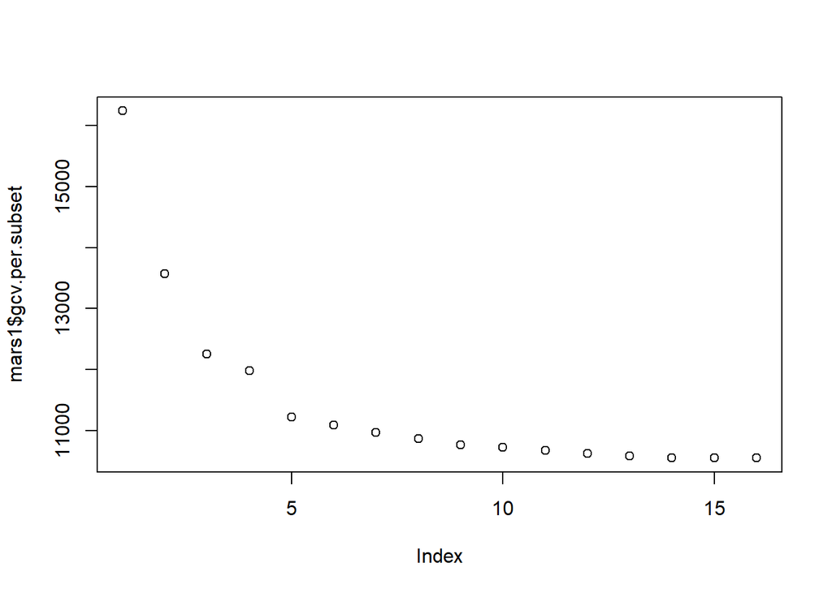

```r
plot(mars1$gcv.per.subset)
```

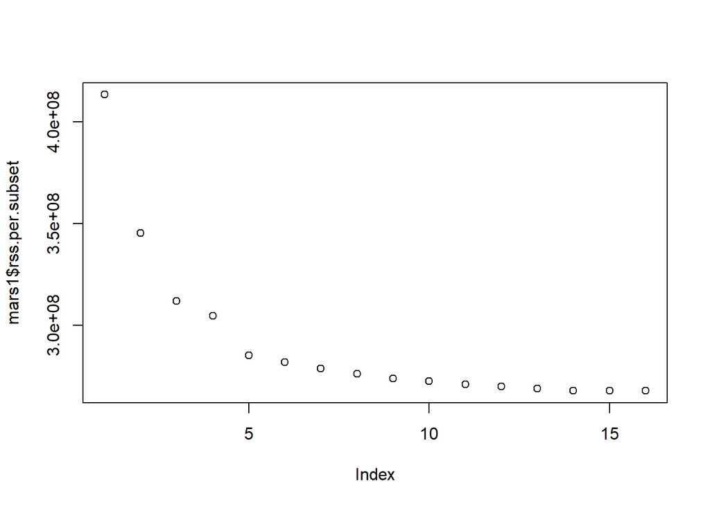

```r
plot(mars1$rss.per.subset)
```

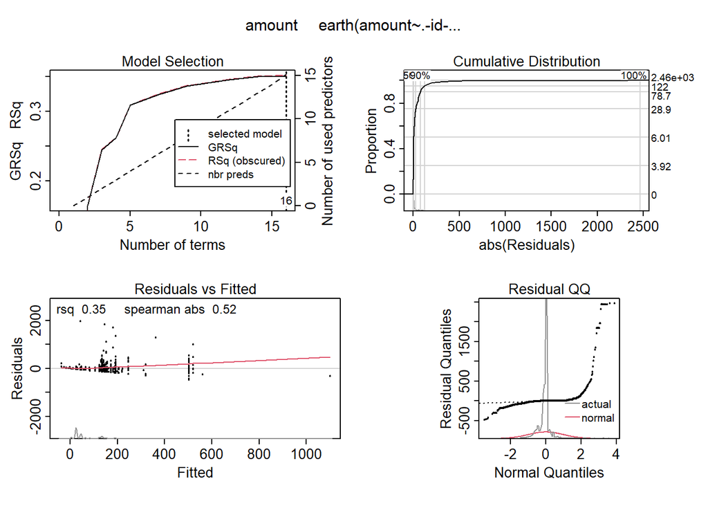

```r
plot(mars1, info = T)
```

## **Porównanie miar RMSE dla zbudowanych modeli**

Najmniejsza miara RMSE okazała się dla modelu drzewa regresyjnego, z którego usunięto obserwacje odbiegające. Ten zabieg pozwolił na zmniejszenie RMSE o około 50. Największe miary RMSE okazały się dla modelu MARS oraz dla modelu regresji liniowej.

```r
vec.names = c("Drzewo regresyjne", "Drzewo regresyjne bez obserwacji odbiegających", "Model regresji liniowej", "MARS")
vec.rmse = c(RMSE.reg.drzewo.first, RMSE.reg.drzewo.final, RMSE.model, RMSE.mars)
rmse.podsumowanie <- data.frame("Model" = vec.names,
                                "RMSE" = vec.rmse)

rmse.podsumowanie %>%
  kbl(caption = "Wartość miar RMSE dla poszczególnych modeli") %>%
  kable_paper("hover", full_width = F, position = "left")
```

Wartość miar RMSE dla poszczególnych modeli

| Model | RMSE |
| --- | --- |
| Drzewo regresyjne | 81.63780 |
| Drzewo regresyjne bez obserwacji odbiegających | 30.54594 |
| Model regresji liniowej | 101.82210 |
| MARS | 102.60019 |

#### Usunięcie niepasujących rekordów

Usunięcie niepasujących rekordów jest konieczne, ponieważ w trakcie procesu ujednolicania poziomów zmiennych typu **factor** powstały wartości NA, które uniemożliwiały wykonanie poszczególnych funkcji. Sam proces ujednolicania poziomów również był konieczny do zrealizowania projektu, ponieważ tak jak w przypadku wartości NA, niektóre funkcje nie działały, gdy zmienne miały różne poziomy czynników.

```r
which(!(predykcje_testowa$id %in% proba_testowa_final$id))
```

```
##  [1]  1991  1992  1993  1994  1995  1996  4173  4174  4175  4176  4177  4178
## [13]  7076  7077  7994  7995  7996  7997  7998  7999  8000  8001  8002  8003
## [25]  8004  8005  8006  8482  8483  8484 10077 10078 10079 12583 12584 12585
## [37] 12586 13079 13080 13081 13340
```

```r
predykcje_testowa <- predykcje_testowa[-c(13079, 13080, 13081, 1991, 1992, 1993, 1994, 1995, 1996, 4167,
                                          4174,  4175,  4176,  4177,  4178,  7076,  7077,  7994,  7995,  7996,  7997,
                                          7998,  7999,  8000,  8001,  8002, 8003,  8004, 8005,  8006,  8482,  8483,
                                          8484, 10077, 10078, 10079, 12583, 12584, 12585, 12586, 13079, 13080, 13081, 13340),]
```

## **Zapisanie wartości zmiennej “amount” do próby testowej na podstawie modelu drzewa regresyjnego bez wartości odbiegających**

Ostateczne wyniki, dokonane na próbie testowej zostały zapisane do pliku **predykcje_testowe.RData** oraz podsumowane poniżej.

```r
drzewo.reg.pred.fin <- predict(new.drzewo_przyciete.reg, proba_testowa_final)
proba_testowa_final$amount <- drzewo.reg.pred.fin

head(proba_testowa_final)
```

```
##      id          createtime     description acquirerconnectionmethod
## 1  2702 2020-07-08 16:50:17 Orange On-line:                 FDP_SOAP
## 2 13081 2020-08-08 16:50:14 Orange On-line:                 FDP_SOAP
## 3 24953 2020-09-08 16:50:09 Orange On-line:                 FDP_SOAP
## 4 37326 2020-10-08 16:50:17 Orange On-line:                 FDP_SOAP
## 5 49909 2020-11-08 16:50:22 Orange On-line:                 FDP_SOAP
## 6 61613 2020-12-08 16:50:28    Orange Flex:                 FDP_SOAP
##   expirymonth expiryyear issuer  type   level countrycode  listtype
## 1           1       2025   VISA DEBIT PREPAID          PL ECOMMERCE
## 2           1       2025   VISA DEBIT PREPAID          PL ECOMMERCE
## 3           1       2025   VISA DEBIT PREPAID          PL ECOMMERCE
## 4           1       2025   VISA DEBIT PREPAID          PL ECOMMERCE
## 5           1       2025   VISA DEBIT PREPAID          PL ECOMMERCE
## 6           1       2025   VISA DEBIT PREPAID          PL ECOMMERCE
##                                             mccname   weekDay  status   amount
## 1 Usługi biznesowe gdzie indziej nie sklasyfikowane     środa success 26.25573
## 2 Usługi biznesowe gdzie indziej nie sklasyfikowane    sobota success 26.25573
## 3 Usługi biznesowe gdzie indziej nie sklasyfikowane    wtorek success 26.25573
## 4 Usługi biznesowe gdzie indziej nie sklasyfikowane  czwartek success 26.25573
## 5 Usługi biznesowe gdzie indziej nie sklasyfikowane niedziela success 26.25573
## 6 Usługi biznesowe gdzie indziej nie sklasyfikowane    wtorek success 26.25573
```

```r
tail(proba_testowa_final)
```

```
##           id          createtime  description acquirerconnectionmethod
## 13479 161630 2021-07-06 16:09:18 Orange Flex:                 FDP_SOAP
## 13480 162222 2021-07-07 15:22:02 Orange Flex:                 FDP_SOAP
## 13481 161967 2021-07-07 07:47:09   Brak opisu               ECARD_REST
## 13482 162088 2021-07-07 10:59:38 Orange Flex:                 FDP_SOAP
## 13483 162106 2021-07-07 11:29:51 Orange Flex:                 FDP_SOAP
## 13484 162176 2021-07-07 13:50:43 Orange Flex:                 FDP_SOAP
##       expirymonth expiryyear     issuer   type    level countrycode  listtype
## 13479          10       2022       VISA  DEBIT     GOLD          PL ECOMMERCE
## 13480           6       2025       VISA  DEBIT  CLASSIC          PL ECOMMERCE
## 13481           4       2023       VISA  DEBIT  CLASSIC          PL ECOMMERCE
## 13482           7       2026 MASTERCARD CREDIT BUSINESS          NL ECOMMERCE
## 13483           7       2026 MASTERCARD CREDIT BUSINESS          NL ECOMMERCE
## 13484           5       2025 MASTERCARD  DEBIT STANDARD          PL ECOMMERCE
##                                                 mccname weekDay  status
## 13479 Usługi biznesowe gdzie indziej nie sklasyfikowane  wtorek success
## 13480 Usługi biznesowe gdzie indziej nie sklasyfikowane   środa success
## 13481 Usługi biznesowe gdzie indziej nie sklasyfikowane   środa success
## 13482 Usługi biznesowe gdzie indziej nie sklasyfikowane   środa success
## 13483 Usługi biznesowe gdzie indziej nie sklasyfikowane   środa success
## 13484 Usługi biznesowe gdzie indziej nie sklasyfikowane   środa success
##          amount
## 13479  26.25573
## 13480  26.25573
## 13481 100.22800
## 13482  26.25573
## 13483  26.25573
## 13484  26.25573
```

```r
summary(proba_testowa_final$amount)
```

```
##    Min. 1st Qu.  Median    Mean 3rd Qu.    Max.
##    8.70   26.26   26.26   46.67   50.31  455.81
```

```r
summary(proba_testowa_final$status)
```

```
##    fail success
##     495   12951
```

```r
predykcje_testowa$amount <- proba_testowa_final$amount
predykcje_testowa$status <- proba_testowa_final$status
summary(predykcje_testowa)[,2:3]
```

```
##      amount           status
##  Min.   :  8.70   fail   :  495
##  1st Qu.: 26.26   success:12951
##  Median : 26.26
##  Mean   : 46.67
##  3rd Qu.: 50.31
##  Max.   :455.81
```

```r
save(predykcje_testowa, file = "predykcje_testowe.RData")
```

## **Podsumowanie wyników projektu**

W przypadku modeli stworzonych na potrzeby zadania pierwszego, najlepszym modelem okazał się model **Random Forest**. Posiadał on największą miarę F oraz wysokie wartości pozostałych miar. Błąd OOB oraz błąd na zbiorze testowych (tu walidacyjnym) malał wraz ze wzrostem ilości generowanych drzew. W naszej opinii, ten model byłby najskuteczniejszy do klasyfikacji zmiennej **status** i modelowania badanego problemu.

Modele stworzone do realizacji zadania drugiego miały na celu dokonać predykcji zmiennej ilościowej **amount**. Zostały zbudowane cztery takie modele i były to modele: drzewa regresyjnego, drzewa regresyjnego bez jednostek nietypowych, model regresji liniowej oraz MARS. Najlepszym modelem okazał się model **drzewa regresyjnego pozbawionego jednostek odbiegających**. Posiadał on najniższą miarę RMSE oraz najwyższy współczynnik pseudo-R2. Sam model jednak trudny jest do bezpośredniej interpretacji, ponieważ wygenerowany na jego podstawie wykres drzewa jest mało czytelny, lecz wartości obliczonych miar powodują, że do zbadania danego problemu, ten model okazał się odpowiedniejszy.